# Lab 13: Grammar of Graphics

You’ll need one new package today, something I wrote called smodels:

```r
# devtools::install_github("statsmaths/smodels")
```

Then, read in the standard libraries.

```r
knitr::opts_chunk$set(echo = TRUE)
library(readr)
library(ggplot2)
library(dplyr)
library(smodels)
theme_set(theme_minimal())
```

## Tea Reviews

Here, we will take look at a dataset of tea reviews from Adagio Teas:

```r
tea <- read_csv("https://statsmaths.github.io/stat_data/tea.csv")
```

With the following variables:

- name: the full name of the tea
- type: the type of tea. One of:
  - black
  - chai
  - decaf
  - flavors
  - green
  - herbal
  - masters
  - matcha
  - oolong
  - pu_erh
  - rooibos
  - white
- score: user rated score; from 0 to 100
- price: estimated price of one cup of tea in cents
- num_reviews: total number of online reviews

Draw a scatter plot with num_reviews (x-axis) against score (y-axis):

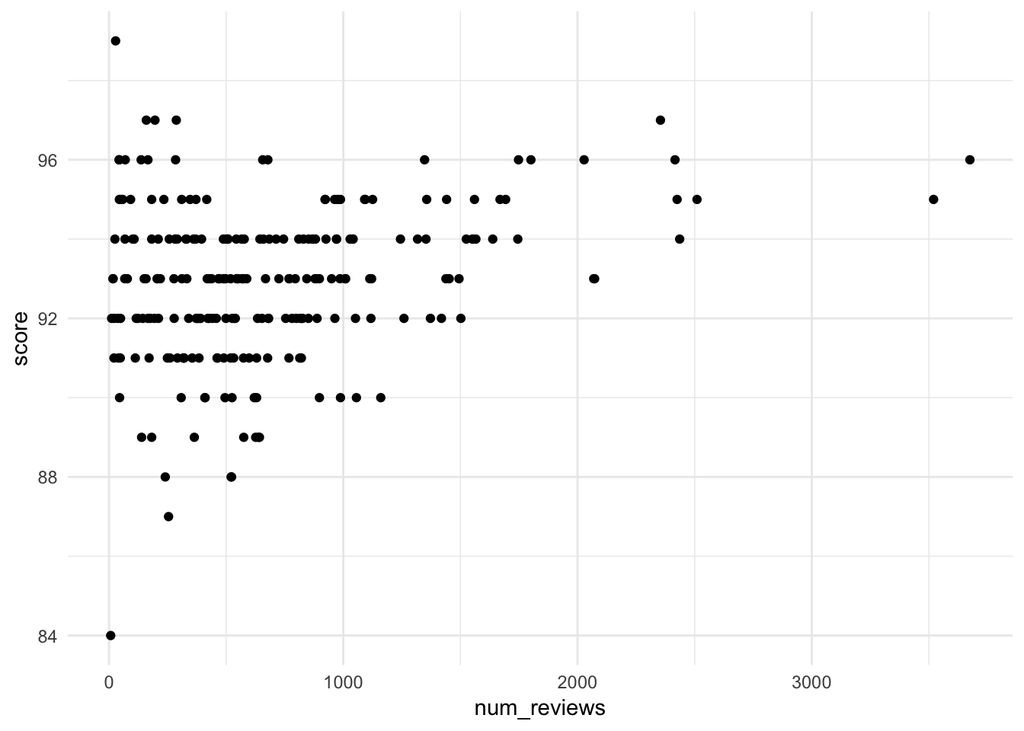

```r
ggplot(tea, aes(num_reviews, score)) +
  geom_point()
```

Now add a best fit line to the scatter plot:

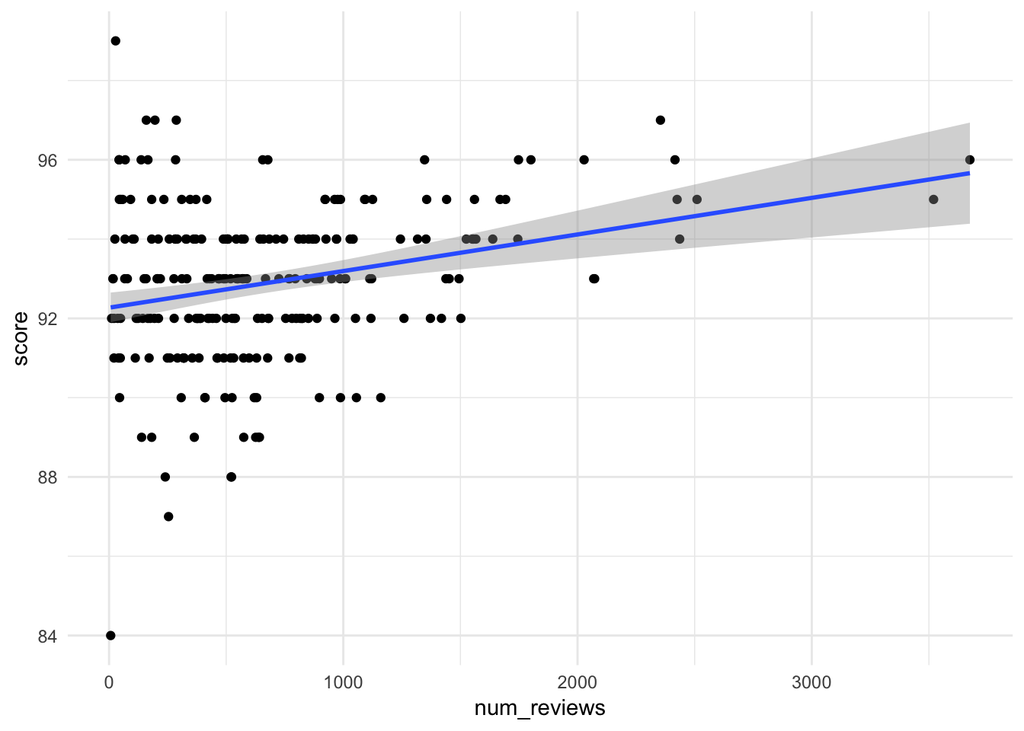

```r
ggplot(tea, aes(num_reviews, score)) +
  geom_point() +
  geom_bestfit()
```

Does the score tend to increase, decrease, or remain the same as the number of reviews increases?

**Answer**: It increases.

Create a text plot with score (x-axis) against price (y-axis) using the tea name as a label. What is the most expensive tea in the data?

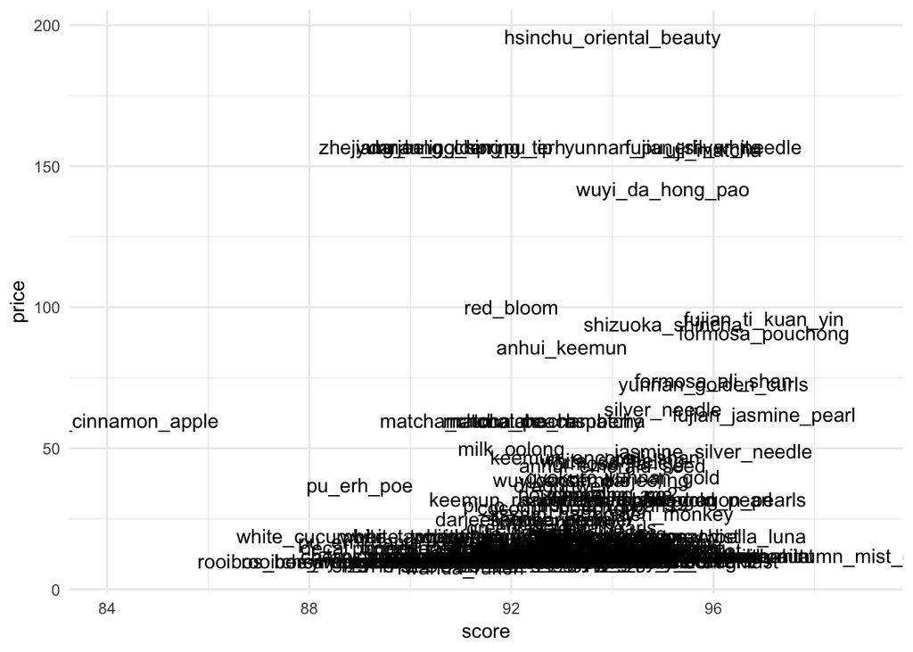

```r
ggplot(tea, aes(score, price)) +
  geom_text(aes(label = name))
```

**Answer**: The most expensive tea is “Hsinchu Oriental Beauty”

Which tea has the lowest score? Does it have a high price per cup?

**Answer**: The tea with the lowest score is Match Cinnamon Apple (you may not have seen the word match; it gets cut off on the left side of the plot).

Create a scatter plot of with num_reviews (x-axis) against score (y-axis) and a facet by tea type:

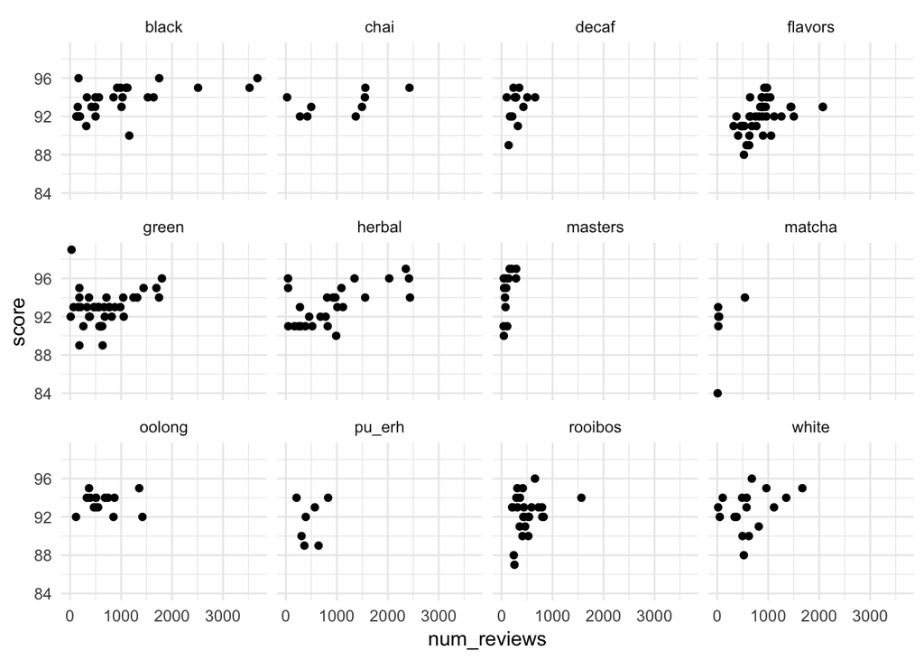

```r
ggplot(tea, aes(num_reviews, score)) +
  geom_point() +
  facet_wrap(~type)
```

Repeat the above plot but allow the scales to be float freely:

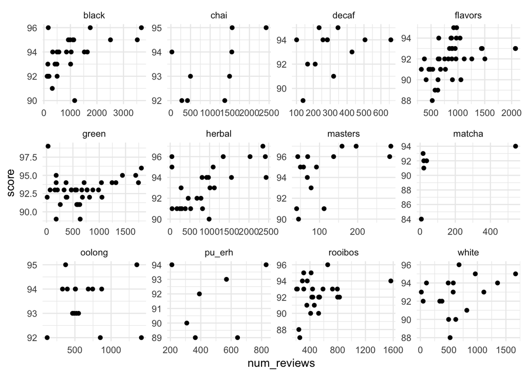

```r
ggplot(tea, aes(num_reviews, score)) +
  geom_point() +
  facet_wrap(~type, scales="free")
```

Which of the two facet plots do you find more readable and why? (Hint: there is not a right answer here)

**Answer**: I think the first is a lot nicer and easier to read. The scales are not so far off as to make the second plot easier and all of the variables can be reasonably compared across the different types of tea (we will later see examples, such as histograms, where the meaning of the y-axis changes with the type of tea).

## Exploratory Analysis of Car Speeding Data

To see some of the commands that we will be looking at next time, let’s grab one more dataset. The data here concerns a study that measured the speed at which cars were traveling. From the documentation:

> In a study into the effect that warning signs have on speeding patterns, Cambridgeshire County Council considered 14 pairs of locations. The locations were paired to account for factors such as traffic volume and type of road. One site in each pair had a sign erected warning of the dangers of speeding and asking drivers to slow down. No action was taken at the second site. Three sets of measurements were taken at each site. Each set of measurements was nominally of the speeds of 100 cars but not all sites have exactly 100 measurements. These speed measurements were taken before the erection of the sign, shortly after the erection of the sign, and again after the sign had been in place for some time.

To read the dataset in, run the following line of code (if you get an error, you probably forgot to run the code at the top of the file):

```r
amis <- read_csv("https://raw.githubusercontent.com/statsmaths/stat_data/gh-pages/amis.csv")
```

Open the dataset in the data viewer. You’ll see four variables: the observed speed of the car, the period of the observation (whether it was before signs were put up, right after, or far after they were put up), a variable warning indicating whether a location had a sign erected, and “location” indicating one of 14 location pairs.

The following command plots the average value for each period colored by whether there was a warning given or not:

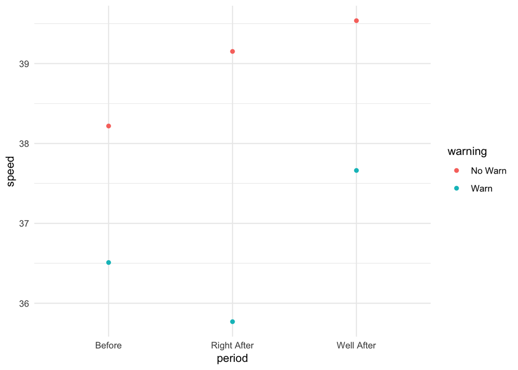

```r
ggplot(amis, aes(period, speed)) +
  geom_mean(aes(color = warning))
```

How would you explain the observed effects in words? Does it seem from this plot that the signs had their indented effect of slowing traffic?

**Answer**: The speeds decrease right after the warning, however they actually rise in the “well after period”. Also, the effect size is fairly small across all time periods.

The following command plots the average speed at each pair of locations based on whether there was a warning sign or not **in the before period*. That is, these measurements come before any signs were put in place.

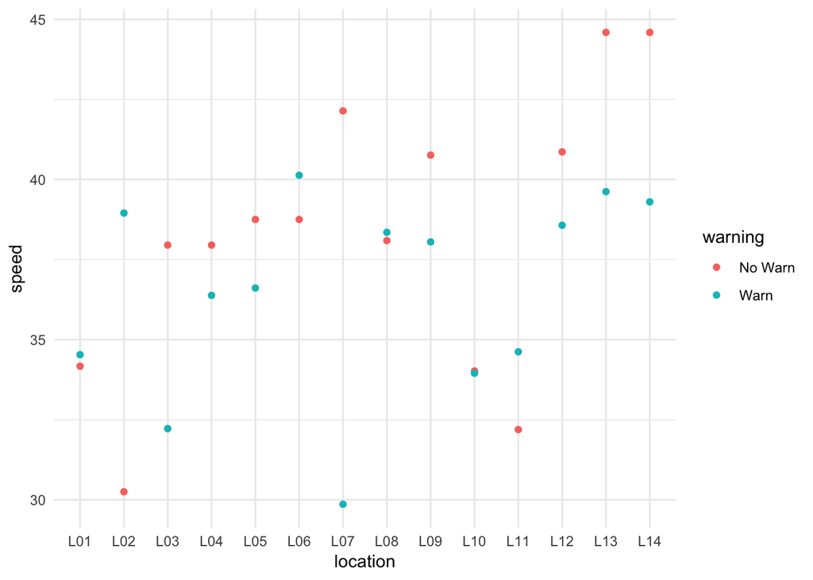

```r
ggplot(filter(amis, period == "Before"), aes(location, speed)) +
  geom_mean(aes(color = warning))
```

The study design suggests that the pairs of locations indicate similar road conditions. Does this seem correct to you based on this plot? What locations seem particularly suspicious?

**Answer**: A few locations look a lot different, including L02, L03, L07, L13, and L14. The L07 seems to be extremely different.